# dodgers_attendance_analysis

## Author: Gabriel Vance

## Class: DSC630 - Predictive Analytics

## Professor: Professor Andrew Hua

## Date: September 23, 2025

# Purpose: This notebook performs the tasks outlined in 3.2 Assignment: Using Data to Improve MLB Attendance. Data from Dodgers 2022 season will be used and insights will be drawn to improve attendance.

```python
# Imports
import pandas as pd
import numpy as np
import matplotlib.pyplot as plt
from scipy.stats import f_oneway

# Suppress warnings for cleaner output
import warnings
warnings.filterwarnings("ignore")

# Ensure that all code cells are fully visible without scrolling
from IPython.core.display import display, HTML

display(HTML('''
<style>
div.CodeMirror pre {
    white-space: pre !important;
}
</style>
'''))
```

```python
# Read data in
df = pd.read_csv('dodgers-2022.csv')
```

```python
# Display the first few rows of the dataframe to understand its structure
df.head()
```

|  | month | day | attend | day_of_week | opponent | temp | skies | day_night | cap | shirt | fireworks | bobblehead |
| --- | --- | --- | --- | --- | --- | --- | --- | --- | --- | --- | --- | --- |
| 0 | APR | 10 | 56000 | Tuesday | Pirates | 67 | Clear | Day | NO | NO | NO | NO |
| 1 | APR | 11 | 29729 | Wednesday | Pirates | 58 | Cloudy | Night | NO | NO | NO | NO |
| 2 | APR | 12 | 28328 | Thursday | Pirates | 57 | Cloudy | Night | NO | NO | NO | NO |
| 3 | APR | 13 | 31601 | Friday | Padres | 54 | Cloudy | Night | NO | NO | YES | NO |
| 4 | APR | 14 | 46549 | Saturday | Padres | 57 | Cloudy | Night | NO | NO | NO | NO |

### Task: Get a sense of the range of attendance values and the overall distribution of attendance.

```python
min_attend = df['attend'].min()
max_attend = df['attend'].max()

print(f"Minimum attendance: {min_attend}")
print(f"Maximum attendance: {max_attend}")
```

```
Minimum attendance: 24312
Maximum attendance: 56000
```

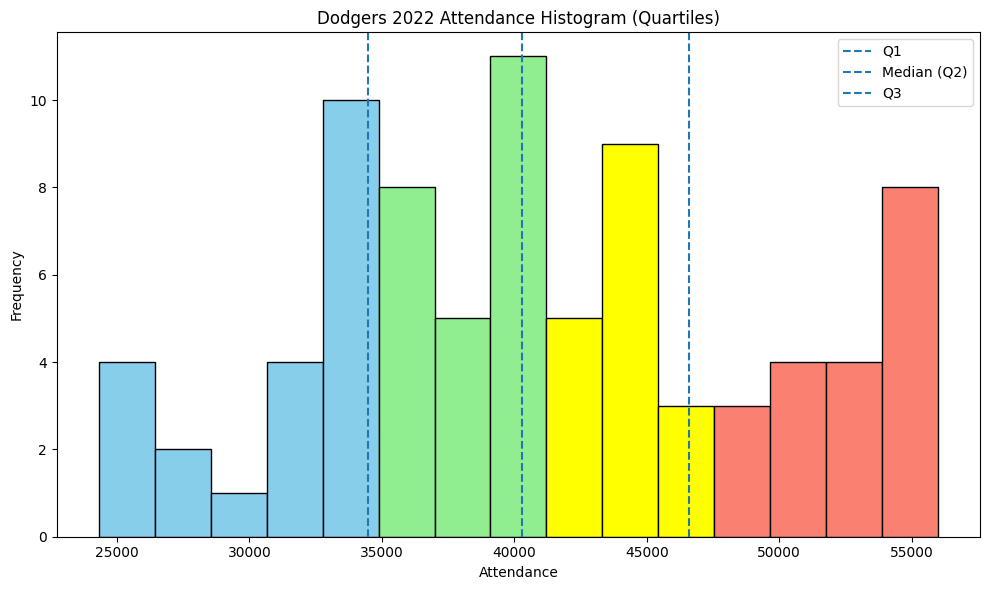

```python
# Calculate quartiles
q1 = df['attend'].quantile(0.25)
q2 = df['attend'].quantile(0.5)
q3 = df['attend'].quantile(0.75)

# Plot histogram with quartile coloring
plt.figure(figsize=(10,6))
n, bins, patches = plt.hist(df['attend'], bins=15, edgecolor='black')

# Color bins by quartile
for patch, left_edge in zip(patches, bins[:-1]):
    if left_edge < q1:
        patch.set_facecolor('skyblue')
    elif left_edge < q2:
        patch.set_facecolor('lightgreen')
    elif left_edge < q3:
        patch.set_facecolor('yellow')
    else:
        patch.set_facecolor('salmon')

plt.axvline(q1, linestyle='--', label='Q1')
plt.axvline(q2, linestyle='--', label='Median (Q2)')
plt.axvline(q3, linestyle='--', label='Q3')
plt.xlabel('Attendance')
plt.ylabel('Frequency')
plt.title('Dodgers 2022 Attendance Histogram (Quartiles)')
plt.legend()
plt.tight_layout()
plt.show()
```

```python
# Calculate the skewness using pandas
skewness = df['attend'].dropna().skew()
print(f"Skewness (pandas): {skewness:.3f}")
```

```
Skewness (pandas): 0.138
```

### Task: To better understand the attendance, we'll create a line chart showing the historical attendance over the season. This will also help us identify any potential trends over time.

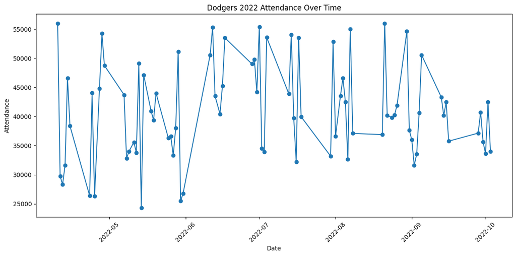

```python
# Create a date column from 'month' and 'day'
df['date'] = pd.to_datetime(df['month'] + ' ' + df['day'].astype(str) + ' 2022', format='%b %d %Y')

# Plot attendance over time
plt.figure(figsize=(12, 6))
plt.plot(df['date'], df['attend'], marker='o')
plt.xlabel('Date')
plt.ylabel('Attendance')
plt.title('Dodgers 2022 Attendance Over Time')
plt.xticks(rotation=45)
plt.tight_layout()
plt.show()
```

### Conclusion: There appear to be maximum attendance spikes slightly above 55,000. The early season's minimum attendance is about 25,000 while the mid to end season is about 33,000. There is no clear trend over time.

### Task: We will create bar charts for various categorical and binary columns to visualize the distribution of attendance based on these factors.

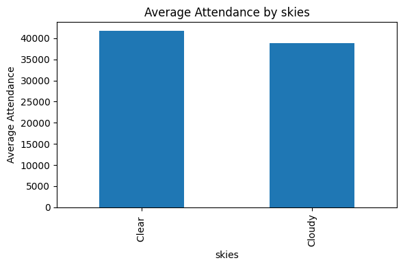

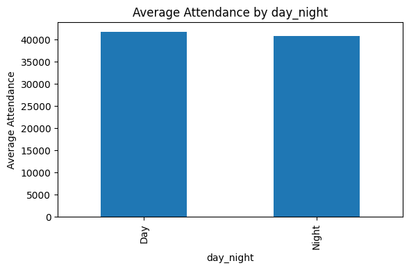

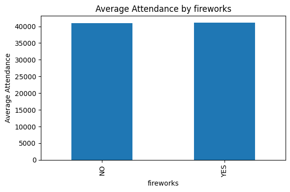

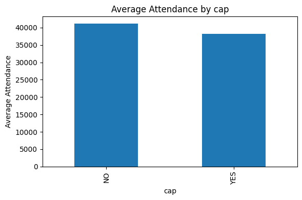

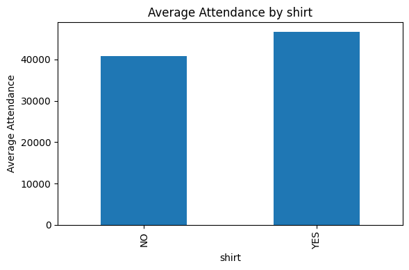

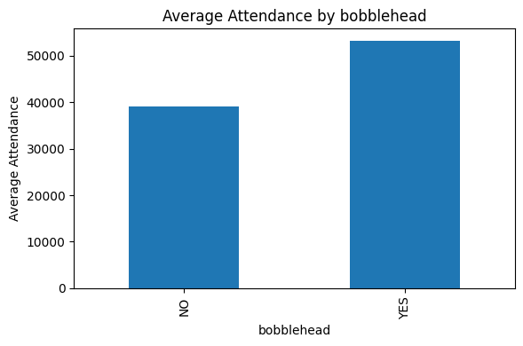

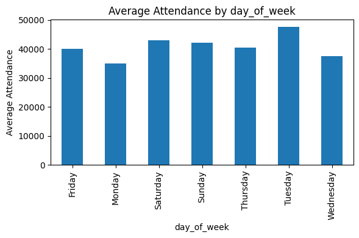

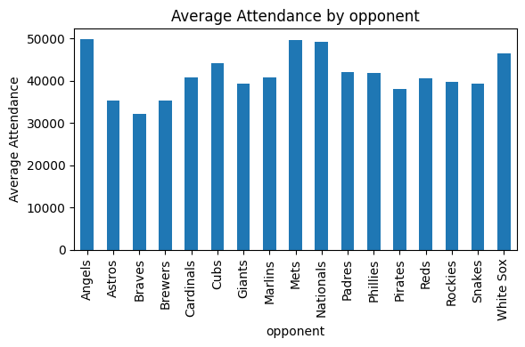

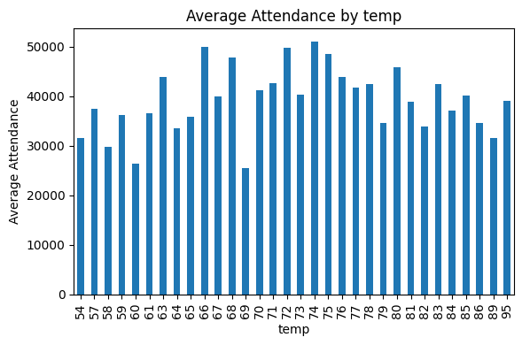

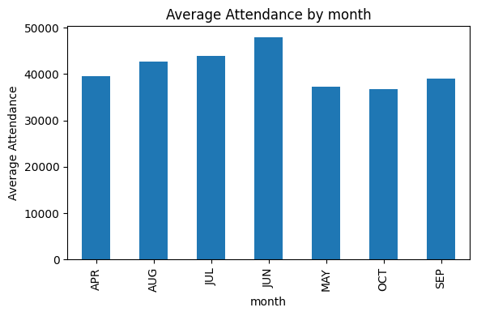

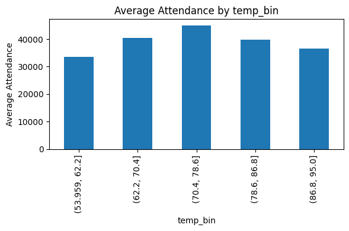

```python
# Add a bin column for temperature because
df['temp_bin'] = pd.cut(df['temp'], bins=5)

columns_to_check = ['skies', 'day_night', 'fireworks', 'cap', 'shirt', 'bobblehead','day_of_week','opponent','temp','month','temp_bin']

for col in columns_to_check:
    avg_attend = df.groupby(col)['attend'].mean()

    # Plot bar chart
    plt.figure(figsize=(6,4))
    avg_attend.plot(kind='bar')

    plt.title(f"Average Attendance by {col}")
    plt.xlabel(col)
    plt.ylabel("Average Attendance")
    plt.tight_layout()
    plt.show()
```

### Task: We'll perform ANOVA tests to determine if there are statistically significant differences in mean attendance based on these factors, but it's pretty clear at this state which factors have the most impact.

```python
# Run ANOVA for each categorical column

results = {}
for col in columns_to_check:
    # get unique non-null group values in a stable order
    groups_vals = df[col].dropna().unique()
    # build groups and drop groups with <=1 observation
    groups = [df.loc[df[col] == val, 'attend'].values for val in groups_vals]
    groups = [g for g in groups if g.size > 1]

    F, p = f_oneway(*groups)
    results[col] = {'F': F, 'p': p, 'n_groups': len(groups)}


# Nicely print results
for col, res in results.items():
    print(f"{col} → F = {res['F']:.5f}, p = {res['p']:.5f} (groups={res['n_groups']})")
```

```
skies → F = 1.84240, p = 0.17854 (groups=2)
day_night → F = 0.15007, p = 0.69951 (groups=2)
fireworks → F = 0.00035, p = 0.98519 (groups=2)
cap → F = 0.23972, p = 0.62576 (groups=2)
shirt → F = 1.42845, p = 0.23559 (groups=2)
bobblehead → F = 40.44392, p = 0.00000 (groups=2)
day_of_week → F = 3.64403, p = 0.00319 (groups=7)
opponent → F = 1.37598, p = 0.18254 (groups=17)
temp → F = 1.28334, p = 0.23723 (groups=20)
month → F = 2.56720, p = 0.02585 (groups=7)
temp_bin → F = 3.67202, p = 0.00868 (groups=5)
```

### Conclusion

Most factors show no significant difference in mean attendance (p > 0.05). Statistically significant effects are:

- bobblehead — large positive effect on attendance (F = 40.444, p < 0.001).
- day_of_week — attendance varies by weekday (F = 3.644, p = 0.003).
- month — attendance varies by month (F = 2.567, p = 0.026).
- temp_bin — attendance varies by temperature bin (F = 3.67202, p = 0.00868).

Binning temperature reduced p from 0.23 to ~0.0087, indicating a nonlinear effect: moderate temperatures increase attendance while extreme cold/hot reduce it.

```python
# Check the occurrences of each opponent
print(df['opponent'].value_counts())
```

```
opponent
Giants       9
Rockies      9
Snakes       9
Padres       9
Cardinals    7
Mets         4
Brewers      4
Pirates      3
Cubs         3
Phillies     3
Reds         3
Astros       3
White Sox    3
Angels       3
Nationals    3
Braves       3
Marlins      3
Name: count, dtype: int64
```

Attendance for games is impacted by several factors. By gauging all possible factors, such as weather, promotional events and schedule, we can find variances to increase attendance.

Over the 2022 season, our attendance fluctuated between lows near 24,000 and highs of 56,000. These extremes are highly unlikely as they represent single data points. For example, opening day had high numbers, but we can't expect to repeat these data points each time.

We have little control over the weather or whether the game is played at night. Fortunately, these factors play a smaller role in attendance than other factors.

Promotional events such as giveaways and fireworks are within our control. Fireworks, shirts, and caps play little role in attendance. However, bobblehead giveaways have a significant impact on attendance.

Overall guidance: